# Perceptual stability ilution

2023-06-12

## Import data

```
## [1] "Analysis"
```

## Explore both df

Demographic df

```
## 'data.frame':    41 obs. of  20 variables:
##  $ participants           : int  1 2 3 4 5 6 7 8 9 10 ...
##  $ prolific               : chr  "5c48c13bcae0ab0001890ce4" "5d1f3c99608da700167a1391" "60a57ec89138a40a4a5acc63" "61082411ae20078aaf317d35" ...
##  $ sleep                  : int  8 8 6 7 9 9 5 8 9 6 ...
##  $ birthday               : chr  "1969-05-02" "2000-01-25" "2001-10-12" "2001-12-28" ...
##  $ country                : chr  "United Kingdom" "Latvia" "Portugal" "Portugal" ...
##  $ sex                    : chr  "Female" "Female" "Male" "Female" ...
##  $ Studies                : chr  "Incomplete university degree" "Incomplete university degree" "Complete university degree" "Complete university degree" ...
##  $ AffectionPsycho_1      : chr  "Yes" "No" "No" "Yes" ...
##  $ AffectionPsycho_2      : chr  "Depression" "NaN" "NaN" "Anxiety" ...
##  $ medication_1           : chr  "Yes" "No" "No" "No" ...
##  $ medication_2           : chr  "fluoxetine" "NaN" "NaN" "NaN" ...
##  $ Browser                : chr  "Chrome 113" "Firefox 113" "Chrome 114" "Chrome 113" ...
##  $ QualityTest            : chr  "You can count on my answers, I participated in the experiment conscientiously and tried to answer honestly." "You can count on my answers, I participated in the experiment conscientiously and tried to answer honestly." "You can count on my answers, I participated…
##  $ Problems               : chr  "NaN" "NaN" "NaN" "NaN" ...
##  $ AQ                     : int  38 15 22 20 33 24 20 20 24 23 ...
##  $ AQ_social              : int  7 3 4 6 9 5 3 5 6 6 ...
##  $ AQ_attentional_switches: int  9 4 8 7 9 5 3 6 9 8 ...
##  $ AQ_attencion_detail    : int  8 3 1 5 7 6 5 6 6 4 ...
##  $ AQ_communication       : int  9 4 4 2 6 4 5 2 2 4 ...
##  $ AQ_imagination         : int  5 1 5 0 2 4 4 1 1 1 ...
```

```
##   participants                 prolific sleep   birthday        country    sex
## 1            1 5c48c13bcae0ab0001890ce4     8 1969-05-02 United Kingdom Female
## 2            2 5d1f3c99608da700167a1391     8 2000-01-25         Latvia Female
## 3            3 60a57ec89138a40a4a5acc63     6 2001-10-12       Portugal   Male
## 4            4 61082411ae20078aaf317d35     7 2001-12-28       Portugal Female
## 5            5 5df5143f58a5c738d0e197af     9 2000-03-15         Poland   Male
## 6            6 5c3885dcf5ebd5000184defb     9 1991-11-27         Greece   Male
##                        Studies AffectionPsycho_1 AffectionPsycho_2 medication_1
## 1 Incomplete university degree               Yes        Depression          Yes
## 2 Incomplete university degree                No               NaN           No
## 3   Complete university degree                No               NaN           No
## 4   Complete university degree               Yes           Anxiety           No
## 5         Complete high school                No               NaN           No
## 6 Complete postgraduate degree                No              None           No
##   medication_2     Browser
```

[output cut: 27 more lines]

Experiment df

```
## 'data.frame':    246 obs. of  5 variables:
##  $ rt          : num  5150 13322 2692 17885 6414 ...
##  $ stimulus    : chr  "videos/fs2yo.mp4" "dot_40_60" "videos/fs1y.mp4" "dot_40" ...
##  $ response    : int  13 79 7 58 28 86 24 40 20 30 ...
##  $ participants: int  1 1 1 1 1 1 2 2 2 2 ...
##  $ trial       : int  1 2 3 4 5 6 1 2 3 4 ...
```

```
##        rt         stimulus response participants trial
## 1  5150.3 videos/fs2yo.mp4       13            1     1
## 2 13322.5        dot_40_60       79            1     2
## 3  2692.2  videos/fs1y.mp4        7            1     3
## 4 17884.8           dot_40       58            1     4
## 5  6413.5  videos/fs1o.mp4       28            1     5
## 6 14497.3           dot_60       86            1     6
```

## Filter by psychiatric condition and medication

```
## [1] "5  participant/s were removed by psychiatric condition"
```

```
## [1] "8  participant/s were removed by medication condition"
```

```
## [1] "Total participants after filter:  33"
```

## Exploratory analysis on AQ

AQ total score

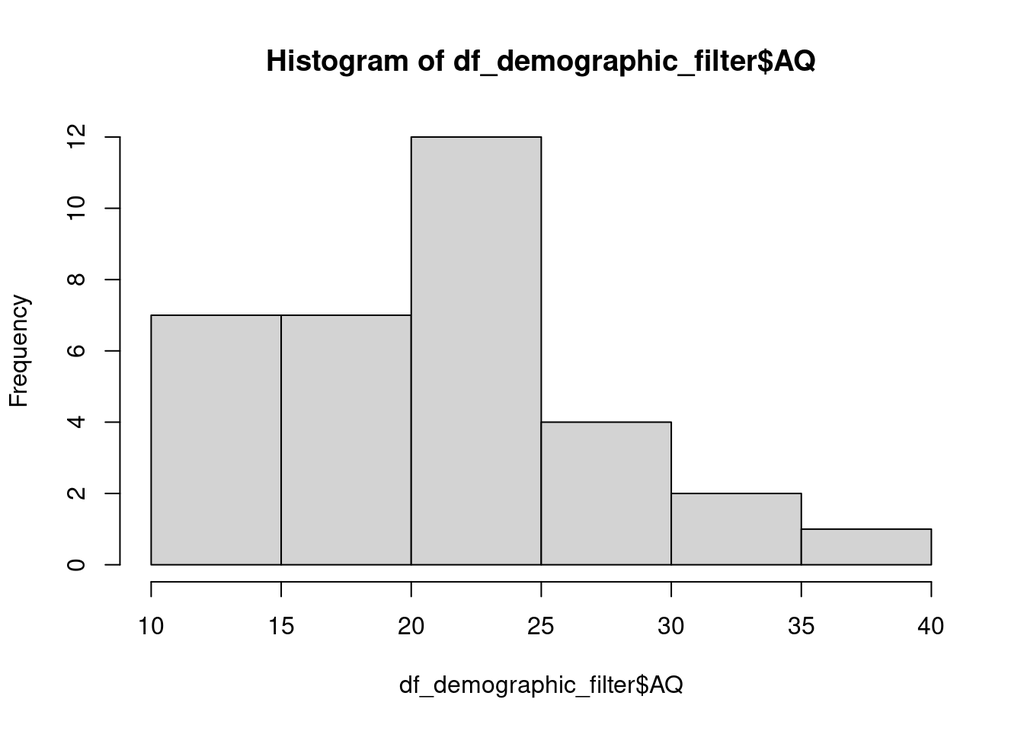

```
##    Min. 1st Qu.  Median    Mean 3rd Qu.    Max.
##   13.00   18.00   21.00   21.48   24.00   36.00
```

AQ total score by sex

```
## [1] "For male: "
```

```
##    Min. 1st Qu.  Median    Mean 3rd Qu.    Max.
##   13.00   16.00   20.00   20.14   23.00   33.00
```

```
## [1] "For female: "
```

```
##    Min. 1st Qu.  Median    Mean 3rd Qu.    Max.
##   13.00   21.25   23.50   23.83   26.25   36.00
```

Inonsistent with previous literature (female:15.4; male: 17.8; Baron-Cohen et al., 2001). Not usual female scoring more than male on AQ.

## Exploratory analysis on face/dots stimuli

```
## # A tibble: 9 × 5
##   stimulus          mean median    se    sd
##   <chr>            <dbl>  <dbl> <dbl> <dbl>
## 1 dot_40            36.9     30  2.68 15.4
## 2 dot_40_60         47.3     40  3.52 20.2
## 3 dot_60            46.8     45  2.24 12.9
## 4 videos/fs1o.mp4   26       26  2.17  8.12
## 5 videos/fs1y.mp4   12.6     10  1.95  7.31
## 6 videos/fs1yo.mp4  19.3     23  1.66  7.24
## 7 videos/fs2o.mp4   22.7     20  1.40  6.10
## 8 videos/fs2y.mp4   14.5     15  1.40  6.10
## 9 videos/fs2yo.mp4  20       20  1.91  7.15
```

It’s kind of weird, because the mean shows that in the dot stimuli there is no apparent effect, but the median does show that there would be an apparent effect. Check the distribution, they may not be Gaussian.

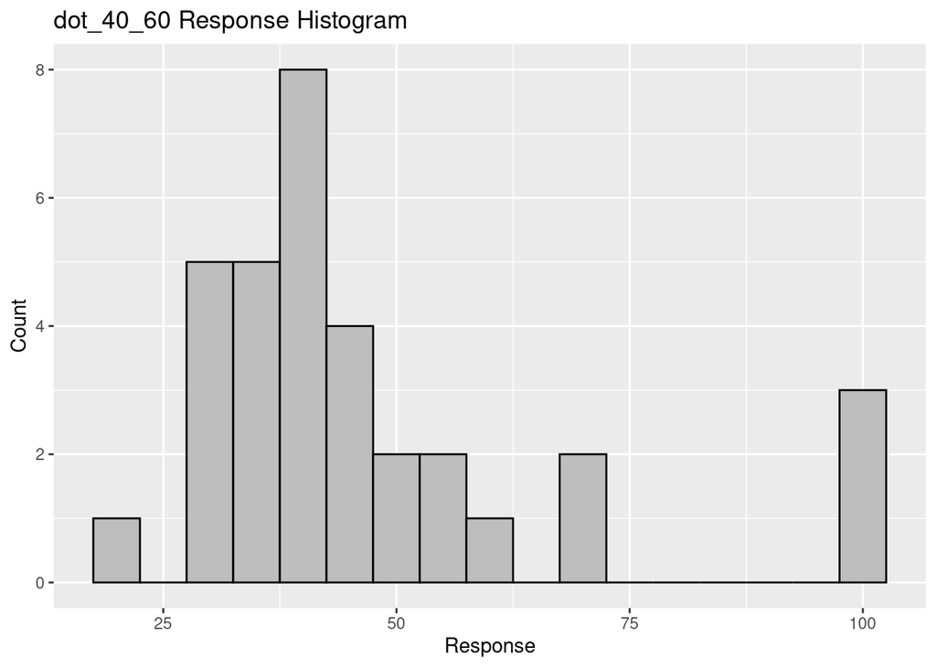

Now it makes sense. The distribution is not Gaussian, there are some answers out of 100. Could these be considered outliers?

I test the other distributions

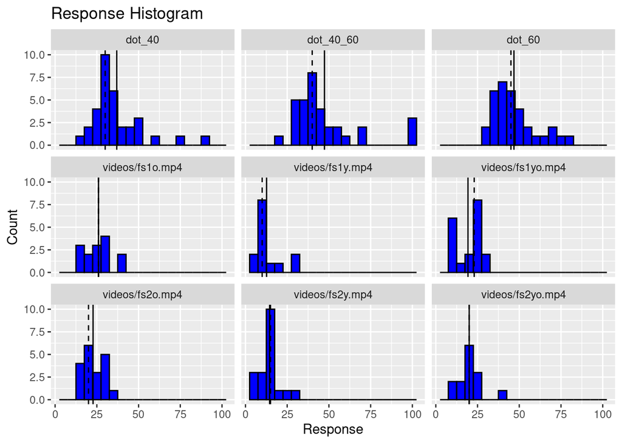

It is interesting to see that the two versions of the face stimulus do show differences between them, I don’t know if they are significant, but you can see differences in mean and median. Check if significant differences are observed.

fs1yo vs fs2yo

```
##
##  Wilcoxon rank sum test with continuity correction
##
## data:  fs1yo$response and fs2yo$response
## W = 144, p-value = 0.701
## alternative hypothesis: true location shift is not equal to 0
```

fs1o vs fs2o

```
##
##  Wilcoxon rank sum test with continuity correction
##
## data:  fs1o$response and fs2o$response
## W = 162.5, p-value = 0.2891
## alternative hypothesis: true location shift is not equal to 0
```

fs1y vs fs2y

```
##
##  Wilcoxon rank sum test with continuity correction
##
## data:  fs1y$response and fs2y$response
## W = 94.5, p-value = 0.1651
## alternative hypothesis: true location shift is not equal to 0
```

There seemed to be differences, but these are not significant. Perhaps because of the size of the sd they present, compared to the difference in means.

Now, I’m going to get two attraction indexes per participant. One will be based on the face stimulus (fs1yo or fs2yo) of the test that was used with the participant, and the second one will be based on the dot stimulus.

DEFINITION 1 “Attraction index was computed by calculating the ratio between the test rating (e.g., old test face) and the absolute difference between the two reference face ratings (e.g., young and old).” Manassi & Whitney, 2022.

In general for dots

```
## [1] "with the mean: "
```

```
## [1] 4.791411
```

```
## [1] "with the median: "
```

```
## [1] 2.666667
```

In general for faces

```
## [1] "with the mean: "
```

```
## [1] 1.877907
```

```
## [1] "with the median: "
```

```
## [1] 1.818182
```

Per participant for dots.

Here I can also observe two ways, and a decision to make. When I calculated de attraction index individually, I could use the individuals responses for the test stimuli and also the individuals responses for the reference stimuli (posibility 1). On the other hand, I could use the individuals responses for the test stimuli but the global mean responses for the reference stimuli (posibility 2). I will calculate attraction index based on both posibilities and look which one works better.

Posibility 1

```
##  [1]  2.666667  6.000000  2.000000  4.000000  3.384615  2.187500       Inf
##  [8]  9.000000       Inf       Inf  1.642857  4.000000  2.333333  1.785714
## [15]  4.000000  6.500000  5.000000  3.000000  3.500000  3.818182  3.000000
## [22]  2.666667  2.666667 14.500000       Inf  3.733333  3.230769 10.000000
## [29]  2.333333  2.000000  3.500000  5.875000  1.052632
```

I can observe that some results are inf. After look what happened, it seems that some participants gave the same response to the few reference stimuli and to the many reference stimuli. When R divides by 0, it shows inf as the results.

Posibility 2 (less probably that it divides by 0)

```
##  [1]  4.049080  5.466258  3.036810  4.049080  4.453988  3.542945  6.073620
##  [8]  4.555215  7.085890 10.122699  4.656442  4.049080  3.542945  5.061350
## [15]  4.049080  5.263804 10.122699  3.036810  3.542945  4.251534  3.036810
## [22]  4.049080  4.049080  2.935583  7.085890  5.668712  4.251534 10.122699
## [29]  3.542945  3.036810  3.542945  4.757669  2.024540
```

```
##  [1] 2.666667 3.600000 2.000000 2.666667 2.933333 2.333333 4.000000 3.000000
##  [9] 4.666667 6.666667 3.066667 2.666667 2.333333 3.333333 2.666667 3.466667
## [17] 6.666667 2.000000 2.333333 2.800000 2.000000 2.666667 2.666667 1.933333
## [25] 4.666667 3.733333 2.800000 6.666667 2.333333 2.000000 2.333333 3.133333
## [33] 1.333333
```

The second posibility worked better. I will continue with this one.

I will add the individual attraction index as a column

Individual attraction index for faces based on definition 1

```
##  [1] 2.3023256 2.6860465 2.1104651 1.1511628 2.1104651 2.3982558 2.8779070
##  [8] 2.3982558 0.8633721 1.7267442 2.3023256 2.3023256 1.9186047 1.1511628
## [15] 0.9593023 0.8633721 1.9186047 2.3982558 0.9593023 1.3430233 1.5348837
## [22] 3.6453488 1.7267442 2.3023256 0.7674419 2.2063953 1.7267442 1.9186047
## [29] 2.2063953 2.3982558 1.5348837 2.3982558 0.8633721
```

```
##  [1] 2.1818182 2.5454545 2.0000000 1.0909091 2.0000000 2.2727273 2.7272727
##  [8] 2.2727273 0.8181818 1.6363636 2.1818182 2.1818182 1.8181818 1.0909091
## [15] 0.9090909 0.8181818 1.8181818 2.2727273 0.9090909 1.2727273 1.4545455
## [22] 3.4545455 1.6363636 2.1818182 0.7272727 2.0909091 1.6363636 1.8181818
## [29] 2.0909091 2.2727273 1.4545455 2.2727273 0.8181818
```

I adding the individual attraction index as a column

DEFINITION 2 of attraction index

They also defined the attraction index in the following way (it is different with regard to the other definition):

“As a measure of the stability illusion strength, we calculated the bias in age ratings toward the beginning of the movie as an attraction index. We computed the absolute difference between test and reference faces (e.g., old reference age − old test face) and divided that by the total age range (e.g., old reference face − young reference face; white circles in Fig. 1, A and B).” Manassi & Whitney, 2022

so:

In general for dots

```
## [1] "with the mean: "
```

```
## [1] 0.05214724
```

```
## [1] "with the median: "
```

```
## [1] 0.3333333
```

In general for faces

```
## [1] "with the mean: "
```

```
## [1] 0.4360465
```

```
## [1] "with the median: "
```

```
## [1] 0.3636364
```

Per participant with the posibility 2 only - for faces

```
##  [1] 0.01162791 0.37209302 0.20348837 1.16279070 0.20348837 0.08430233
##  [7] 0.56395349 0.08430233 1.45058140 0.58720930 0.01162791 0.01162791
## [13] 0.39534884 1.16279070 1.35465116 1.45058140 0.39534884 0.08430233
## [19] 1.35465116 0.97093023 0.77906977 1.33139535 0.58720930 0.01162791
## [25] 1.54651163 0.10755814 0.58720930 0.39534884 0.10755814 0.08430233
## [31] 0.77906977 0.08430233 1.45058140
```

```
##  [1] 0.00000000 0.36363636 0.18181818 1.09090909 0.18181818 0.09090909
##  [7] 0.54545455 0.09090909 1.36363636 0.54545455 0.00000000 0.00000000
## [13] 0.36363636 1.09090909 1.27272727 1.36363636 0.36363636 0.09090909
## [19] 1.27272727 0.90909091 0.72727273 1.27272727 0.54545455 0.00000000
## [25] 1.45454545 0.09090909 0.54545455 0.36363636 0.09090909 0.09090909
## [31] 0.72727273 0.09090909 1.36363636
```

I will add the individual attraction index based on the definition 2 as a column

Per participant with the posibility 2 only - for dots

```
##  [1] 0.69018405 0.72699387 1.70245399 0.69018405 0.28527607 1.19631902
##  [7] 1.33435583 0.18404908 2.34662577 5.38343558 0.08282209 0.69018405
## [13] 1.19631902 0.32208589 0.69018405 0.52453988 5.38343558 1.70245399
## [19] 1.19631902 0.48773006 1.70245399 0.69018405 0.69018405 1.80368098
## [25] 2.34662577 0.92944785 0.48773006 5.38343558 1.19631902 1.70245399
## [31] 1.19631902 0.01840491 2.71472393
```

```
##  [1] 0.33333333 0.60000000 1.00000000 0.33333333 0.06666667 0.66666667
##  [7] 1.00000000 0.00000000 1.66666667 3.66666667 0.06666667 0.33333333
## [13] 0.66666667 0.33333333 0.33333333 0.46666667 3.66666667 1.00000000
## [19] 0.66666667 0.20000000 1.00000000 0.33333333 0.33333333 1.06666667
## [25] 1.66666667 0.73333333 0.20000000 3.66666667 0.66666667 1.00000000
## [31] 0.66666667 0.13333333 1.66666667
```

I will add the individual attraction index based on the definition 2 as a column

## Exploring the relation between AQ and individual Attraction index

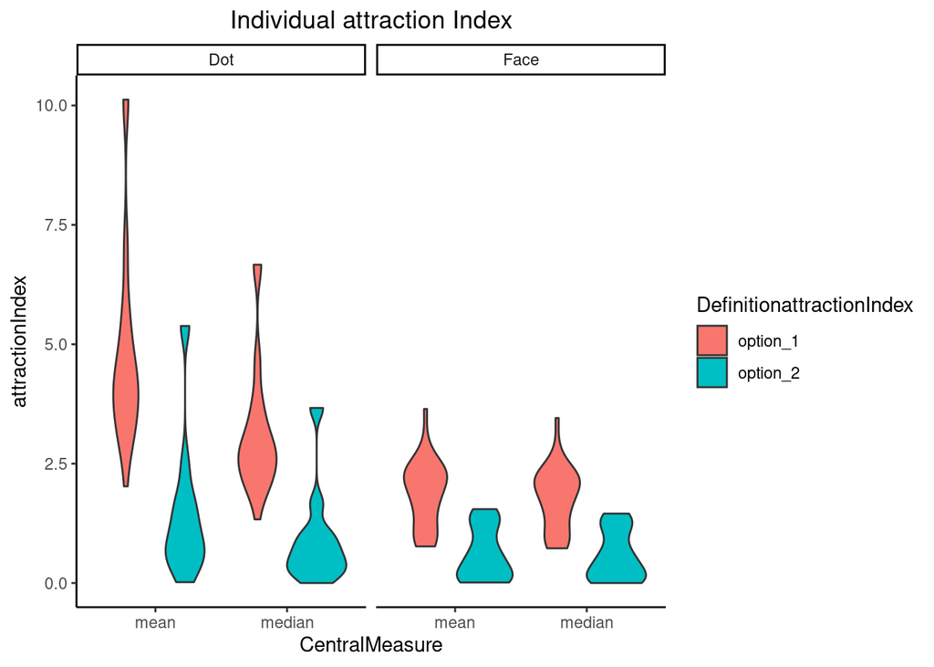

The distribution of individual index attraction seems not normal.

## Relationship between AQ and attraction index

# Some visualization

Faces and AQ

First of all, I will modify the df

Show the data frame new

```
## 'data.frame':    99 obs. of  6 variables:
##  $ rt          : num  4469 2438 1903 7842 3577 ...
##  $ response    : int  24 20 28 28 16 24 22 9 40 12 ...
##  $ participants: int  2 2 2 3 3 3 5 5 5 6 ...
##  $ trial       : int  1 3 5 1 3 5 1 3 5 1 ...
##  $ face_type   : num  0 1 1 0 1 1 1 0 0 0 ...
##  $ face_age    : chr  "morph" "young" "old" "morph" ...
```

```
##       rt response participants trial face_type face_age
## 1 4469.0       24            2     1         0    morph
## 2 2438.0       20            2     3         1    young
## 3 1903.0       28            2     5         1      old
## 4 7841.9       28            3     1         0    morph
## 5 3577.0       16            3     3         1    young
## 6 3759.3       24            3     5         1      old
```

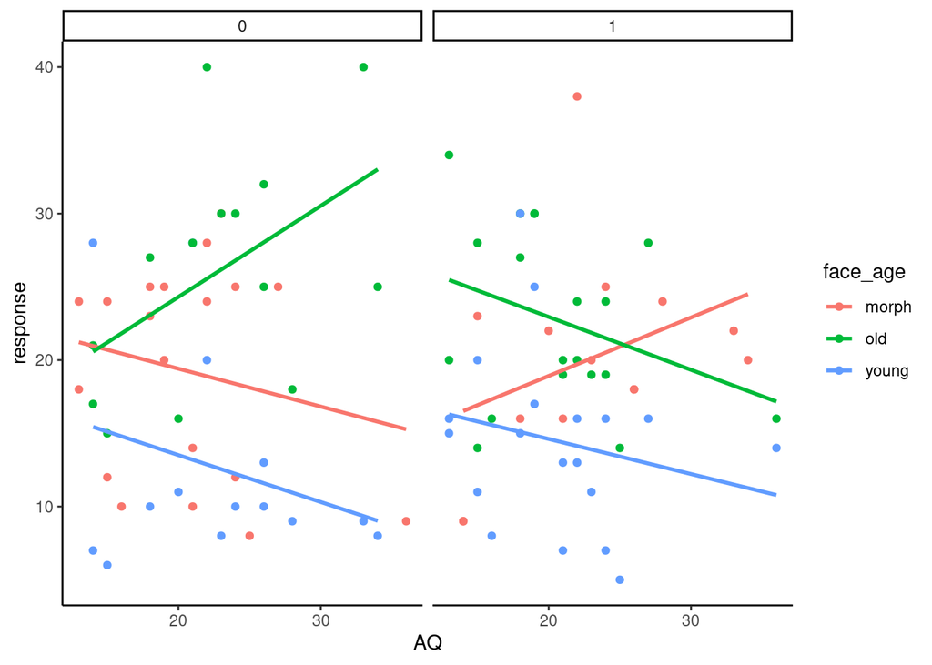

The face 0 and face 1 behave differently regarding AQ (except for the young face).

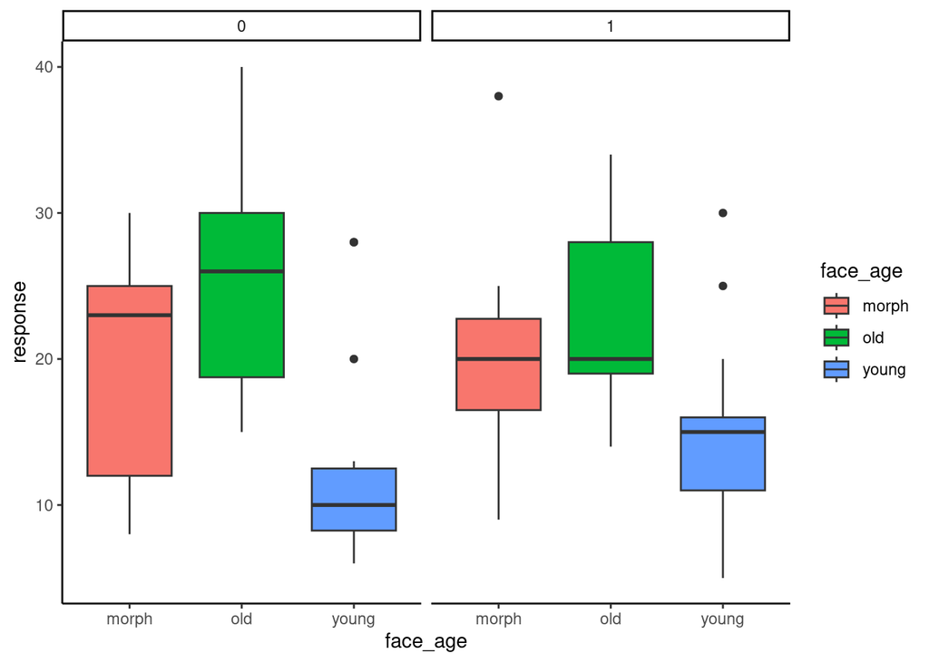

Face 1 does not maximize the effect we are looking for. There does not seem to be much difference between the age reported for young - morph - old. This face was created with a video game program, it doesn’t look very real. Think about whether to discard/replace it.

We will use the spearman correlation

```
## [1] "AQ - Individual attraction Index (mean) based on Option 1 of attraction Index: "
```

```
##
##  Spearman's rank correlation rho
##
## data:  df_demographic_filter$AQ and df_demographic_filter$face_attraction_index_individual_mean_d1
## S = 5276.2, p-value = 0.5121
## alternative hypothesis: true rho is not equal to 0
## sample estimates:
##       rho
## 0.1182753
```

```
## [1] "AQ - Individual attraction Index (median) based on Option 1 of attraction Index: "
```

```
##
##  Spearman's rank correlation rho
##
## data:  df_demographic_filter$AQ and df_demographic_filter$face_attraction_index_individual_median_d1
## S = 5276.2, p-value = 0.5121
## alternative hypothesis: true rho is not equal to 0
## sample estimates:
##       rho
## 0.1182753
```

```
## [1] "AQ - Individual attraction Index (mean) based on Option 2 of attraction Index: "
```

```
##
##  Spearman's rank correlation rho
##
## data:  df_demographic_filter$AQ and df_demographic_filter$face_attraction_index_individual_mean_d2
## S = 6186.7, p-value = 0.8515
## alternative hypothesis: true rho is not equal to 0
## sample estimates:
##         rho
## -0.03387699
```

```
## [1] "AQ - Individual attraction Index (median) based on Option 2 of attraction Index: "
```

```
##
##  Spearman's rank correlation rho
##
## data:  df_demographic_filter$AQ and df_demographic_filter$face_attraction_index_individual_median_d2
## S = 6054.2, p-value = 0.9483
## alternative hypothesis: true rho is not equal to 0
## sample estimates:
##         rho
## -0.01173414
```

Dots and AQ

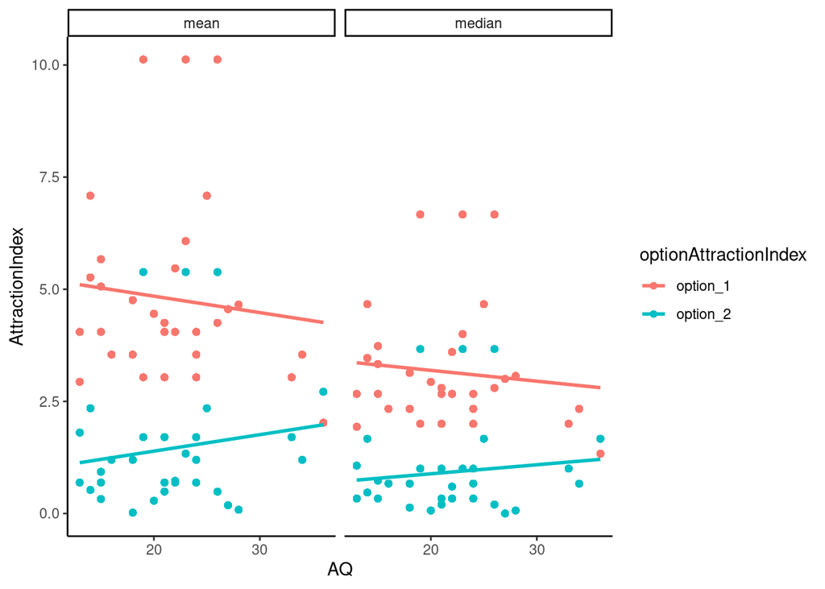

Attraction index options 1 and 2 do not appear to behave equally with respect to AQ.

We will use the spearman correlation

```
## [1] "AQ - Individual attraction Index (mean) based on Option 1 of attraction Index: "
```

```
##
##  Spearman's rank correlation rho
##
## data:  df_demographic_filter$AQ and df_demographic_filter$dot_attraction_index_individual_mean_d1
## S = 6423.5, p-value = 0.6846
## alternative hypothesis: true rho is not equal to 0
## sample estimates:
##         rho
## -0.07345069
```

```
## [1] "AQ - Individual attraction Index (median) based on Option 1 of attraction Index: "
```

```
##
##  Spearman's rank correlation rho
##
## data:  df_demographic_filter$AQ and df_demographic_filter$dot_attraction_index_individual_median_d1
## S = 6423.5, p-value = 0.6846
## alternative hypothesis: true rho is not equal to 0
## sample estimates:
##         rho
## -0.07345069
```

```
## [1] "AQ - Individual attraction Index (mean) based on Option 2 of attraction Index: "
```

```
##
##  Spearman's rank correlation rho
##
## data:  df_demographic_filter$AQ and df_demographic_filter$dot_attraction_index_individual_mean_d2
## S = 5308.6, p-value = 0.5317
## alternative hypothesis: true rho is not equal to 0
## sample estimates:
##       rho
## 0.1128715
```

```
## [1] "AQ - Individual attraction Index (median) based on Option 2 of attraction Index: "
```

```
##
##  Spearman's rank correlation rho
##
## data:  df_demographic_filter$AQ and df_demographic_filter$dot_attraction_index_individual_median_d2
## S = 5763.1, p-value = 0.8384
## alternative hypothesis: true rho is not equal to 0
## sample estimates:
##      rho
## 0.036919
```

## Now I will try another way to see the bias, after speak with pablo and guille

Exploring the relationship between response based on face_type (face 1 or 2) and face_age (morph, old or young )

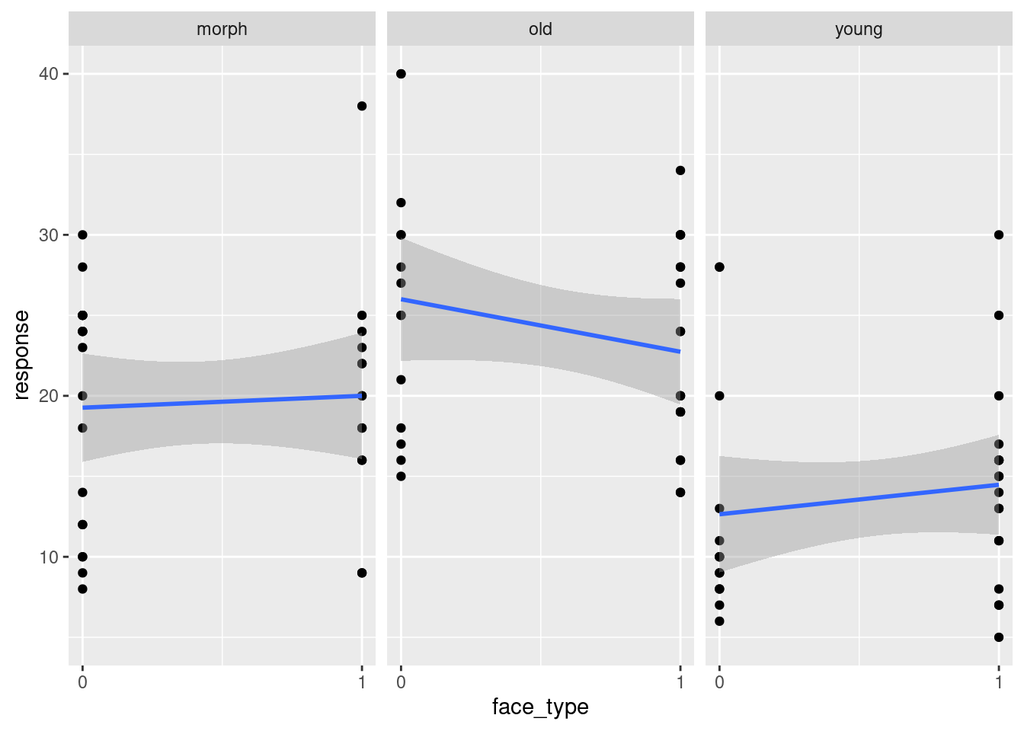

It doesn’t seems to be differences based on the face_type for none of the face_age

Now only the response and face_age

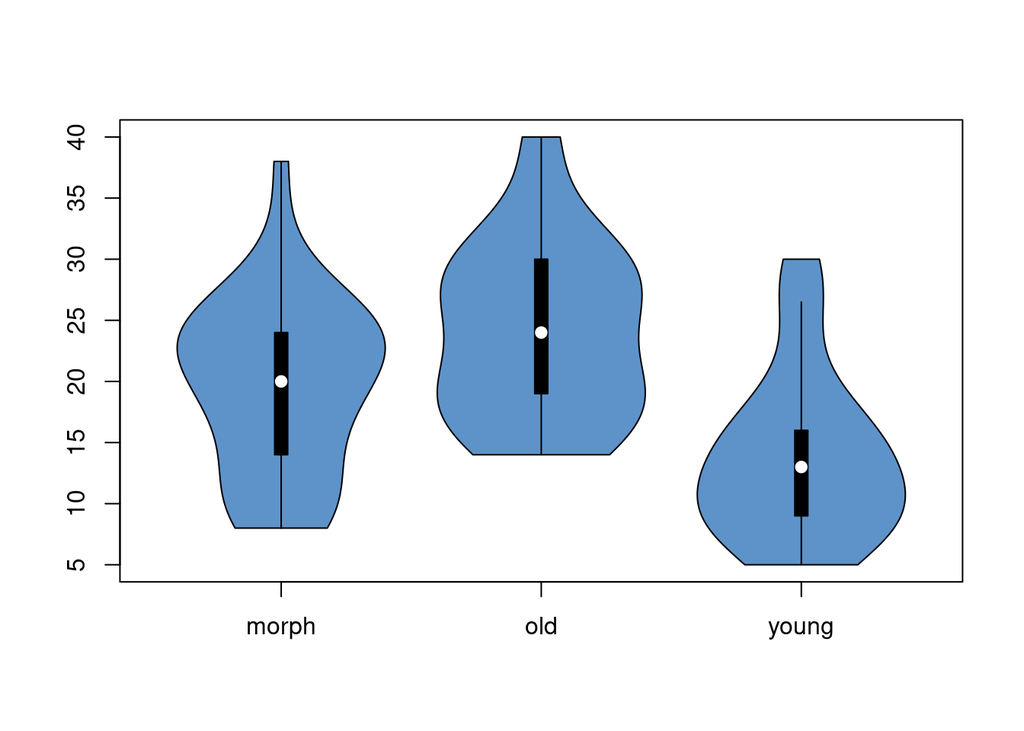

Now I will run the frequentist regression model

model 1

```
##
## Call:
## lm(formula = response ~ face_type + face_age, data = d_faces)
##
## Residuals:
##      Min       1Q   Median       3Q      Max
## -11.6741  -5.3107  -0.0229   4.3259  18.5577
##
## Coefficients:
##               Estimate Std. Error t value Pr(>|t|)
## (Intercept)    19.6741     1.3545  14.525  < 2e-16 ***
## face_type      -0.2318     1.4177  -0.164  0.87045
## face_ageold     4.5806     1.7297   2.648  0.00947 **
## face_ageyoung  -5.8437     1.7297  -3.378  0.00106 **
## ---
## Signif. codes:  0 '***' 0.001 '**' 0.01 '*' 0.05 '.' 0.1 ' ' 1
##
## Residual standard error: 6.972 on 95 degrees of freedom
## Multiple R-squared:  0.2809, Adjusted R-squared:  0.2582
## F-statistic: 12.37 on 3 and 95 DF,  p-value: 6.694e-07
```

Ok. When predicting responses, the face_type (1 or 2) is not a significant predictor. Good new

So, can we take it out?

model 2

```
##
## Call:
## lm(formula = response ~ face_age, data = d_faces)
##
## Residuals:
##      Min       1Q   Median       3Q      Max
## -11.5758  -5.3485  -0.1212   4.4242  18.4242
##
## Coefficients:
##               Estimate Std. Error t value Pr(>|t|)
## (Intercept)     19.576      1.207  16.213  < 2e-16 ***
## face_ageold      4.545      1.708   2.662 0.009109 **
## face_ageyoung   -5.879      1.708  -3.443 0.000855 ***
## ---
## Signif. codes:  0 '***' 0.001 '**' 0.01 '*' 0.05 '.' 0.1 ' ' 1
##
## Residual standard error: 6.936 on 96 degrees of freedom
## Multiple R-squared:  0.2807, Adjusted R-squared:  0.2658
## F-statistic: 18.74 on 2 and 96 DF,  p-value: 1.35e-07
```

Wow, so there is an effect of face_age. Between all categories. More good news.

model 3 (with interactions)

```
##
## Call:
## lm(formula = response ~ face_age * scale(AQ), data = d_faces_NotFace1)
##
## Residuals:
##      Min       1Q   Median       3Q      Max
## -11.2882  -5.6776  -0.3476   4.5129  14.8079
##
## Coefficients:
##                         Estimate Std. Error t value Pr(>|t|)
## (Intercept)              18.9341     1.7275  10.961 9.29e-14 ***
## face_ageold               6.5288     2.6258   2.486   0.0171 *
## face_ageyoung            -6.0147     2.6258  -2.291   0.0272 *
## scale(AQ)                -1.5527     1.8781  -0.827   0.4132
## face_ageold:scale(AQ)     5.2875     2.6807   1.972   0.0553 .
## face_ageyoung:scale(AQ)  -0.3706     2.6807  -0.138   0.8907
## ---
## Signif. codes:  0 '***' 0.001 '**' 0.01 '*' 0.05 '.' 0.1 ' ' 1
##
## Residual standard error: 7.327 on 41 degrees of freedom
## Multiple R-squared:  0.4123, Adjusted R-squared:  0.3407
## F-statistic: 5.754 on 5 and 41 DF,  p-value: 0.0004118
```

model 4

```
##
## Call:
## lm(formula = response ~ face_type * face_age * scale(AQ), data = d_faces)
##
## Residuals:
##     Min      1Q  Median      3Q     Max
## -11.288  -4.527  -1.027   3.877  18.285
##
## Coefficients:
##                                   Estimate Std. Error t value Pr(>|t|)
## (Intercept)                        19.0289     1.5812  12.034  < 2e-16 ***
## face_type                           0.4806     2.4355   0.197  0.84402
## face_ageold                         6.2063     2.4355   2.548  0.01258 *
## face_ageyoung                      -5.9921     2.4355  -2.460  0.01586 *
## scale(AQ)                          -1.5105     1.6946  -0.891  0.37520
## face_type:face_ageold              -3.3061     3.4443  -0.960  0.33978
## face_type:face_ageyoung             0.7397     3.4443   0.215  0.83046
## face_type:scale(AQ)                 3.8406     2.4189   1.588  0.11596
## face_ageold:scale(AQ)               5.1438     2.4189   2.127  0.03629 *
## face_ageyoung:scale(AQ)            -0.3605     2.4189  -0.149  0.88185
## face_type:face_ageold:scale(AQ)    -9.5828     3.4208  -2.801  0.00627 **
## face_type:face_ageyoung:scale(AQ)  -3.3664     3.4208  -0.984  0.32780
## ---
## Signif. codes:  0 '***' 0.001 '**' 0.01 '*' 0.05 '.' 0.1 ' ' 1
##
## Residual standard error: 6.796 on 87 degrees of freedom
## Multiple R-squared:  0.3742, Adjusted R-squared:  0.2951
## F-statistic: 4.729 on 11 and 87 DF,  p-value: 1.187e-05
```

## Now bayes way

Libraries

Lets continue with model 2

The prior for the intercept will be based on the original paper of manassi and whitney 2022. The young face of face 1 was rating as 13 years old The old face of face 1 was rating as 25.5 years old The morph face of face 1 was rating as 20.2 years old

The young face of face 2 (high noise) was rating as 14.8 years old The old face of face 2 (high noise) was rating as 23.8 years old The morph face of face 2 was rating as 20.3 years old

We have no report of the standar deviation of these means, I will use weakly informative prior.

In the model 2 (response ~ face_age), the intercept is the mean of the response when x is 0 (the morph stimuli is the baseline here). So, combining both mean of the morph stimulus (face 1 and 2) we have a mean of 20.25 for the morph stimuli

I will see if the prior is ok with a sd of 10 for the intercept

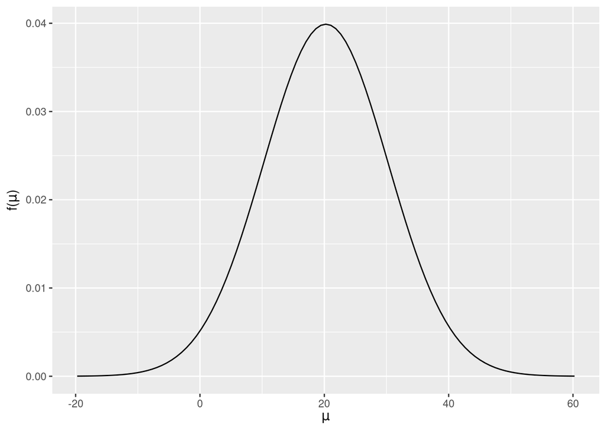

We have negative results as possible but they are unlikely.

We realized that can take out the young face in this way of observe the bias. It is useful when we want to calculate the attraction index as defined by manassi and whytney 2022, but not now

prior check

```
## Priors for model 'm_2_bayesian'
## ------
## Intercept (after predictors centered)
##  ~ normal(location = 20, scale = 10)
##
## Coefficients
##  ~ normal(location = 0, scale = 2)
##
## Auxiliary (sigma)
##   Specified prior:
##     ~ exponential(rate = 1)
##   Adjusted prior:
##     ~ exponential(rate = 2.7)
## ------
## See help('prior_summary.stanreg') for more details
```

MCMC diagnostics

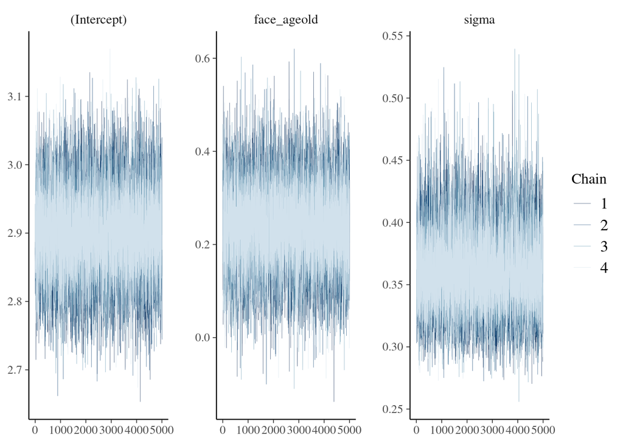

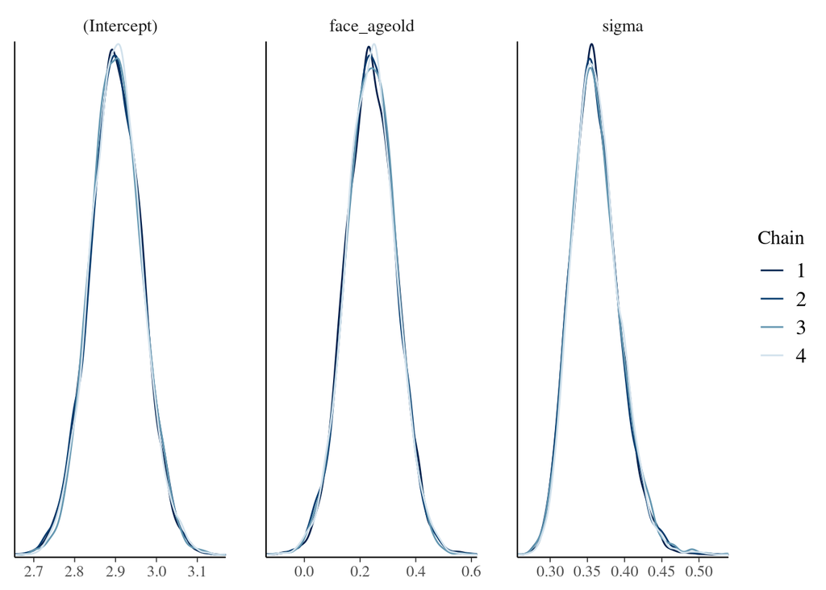

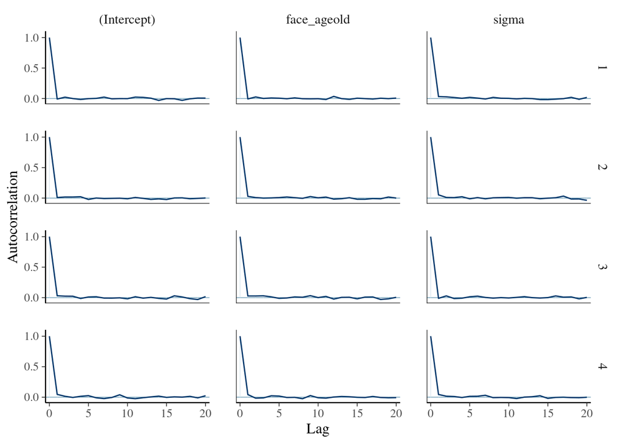

```
## (Intercept) face_ageold       sigma
##      0.9037      0.8745      0.8517
```

```
## (Intercept) face_ageold       sigma
##   0.9999104   0.9999870   1.0001284
```

Exploring postriors

```
##    (Intercept) face_ageold     sigma
## 1     2.868562   0.1940885 0.4089491
## 2     2.886929   0.1911022 0.3726366
## 3     2.879237   0.2950512 0.3664559
## 4     2.865968   0.2692844 0.3533066
## 5     2.871433   0.1847236 0.3670024
## 6     2.861684   0.1027154 0.3578493
## 7     2.970494   0.3188425 0.3701523
## 8     2.851367   0.1435597 0.3434000
## 9     2.868344   0.1756292 0.3638921
## 10    2.837144   0.3954685 0.3647347
```

Posterior summary statistics

```
## # A tibble: 4 × 5
##   term        estimate std.error conf.low conf.high
##   <chr>          <dbl>     <dbl>    <dbl>     <dbl>
## 1 (Intercept)    2.90     0.0632    2.82      2.98
## 2 face_ageold    0.239    0.0897    0.126     0.355
## 3 sigma          0.358    0.0323    0.321     0.403
## 4 mean_PPD       3.02     0.0630    2.94      3.10
```

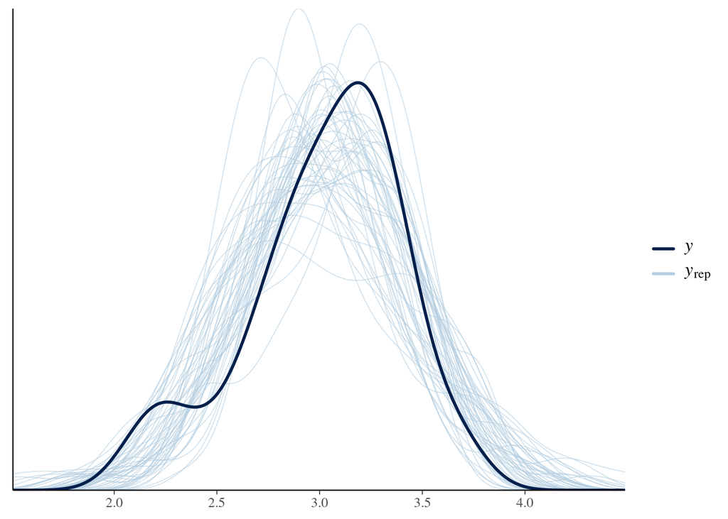

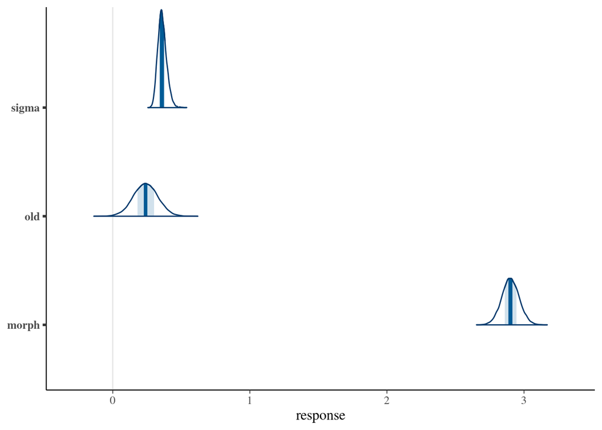